# Homework 2

Sharon Bures

2024-06-14

```r
library(tidyverse)
setwd("~/Uni/DWVT")
accidents <- readRDS('accidents.rds')
head(accidents)
```

```
## # A tibble: 6 × 31
##   id          easting northing longitude latitude police_force severity vehicles
##   <chr>         <dbl>    <dbl>     <dbl>    <dbl>        <dbl> <fct>       <dbl>
## 1 2018950000…  327174   670941     -3.17     55.9           95 Slight          1
## 2 2018950000…  324874   672457     -3.20     55.9           95 Slight          1
## 3 2018950000…  330500   671750     -3.11     55.9           95 Slight          2
## 4 2018950000…  321890   671640     -3.25     55.9           95 Slight          3
## 5 2018950000…  320120   669330     -3.28     55.9           95 Slight          2
## 6 2018950000…  331752   667988     -3.09     55.9           95 Slight          3
## # ℹ 23 more variables: casualties <dbl>, date <chr>, day_of_week <fct>,
## #   time <time>, district <dbl>, highway <chr>, first_road_class <fct>,
## #   first_road_number <chr>, road_type <fct>, speed_limit <dbl>,
## #   junction_detail <chr>, junction_control <chr>, second_road_class <chr>,
## #   second_road_number <chr>, ped_cross_human <chr>, ped_cross_physical <chr>,
## #   light <fct>, weather <fct>, road_surface <fct>, special_condition <fct>,
## #   hazard <fct>, urban_rural <dbl>, police <chr>
```

#### How many observations (rows) does the dataset have? Instead of hard coding the number in your answer, use inline code. Run View(accidents) in your Console to view the data in the data viewer. What does each row in the dataset represent?

```r
View(accidents)
```

There are 768 rows in the dataframe, where each row is an observation, in this case each row bring an accident.

### Which day of the week has the highest number of fatal accidents?

```r
accidents %>%
  filter(severity == 'Fatal') %>%
  count(day_of_week) %>%
  rename(number_accidents = n) %>%
  arrange(-number_accidents)
```

```
## # A tibble: 3 × 2
##   day_of_week number_accidents
##   <fct>                  <int>
## 1 Friday                     3
## 2 Tuesday                    1
## 3 Wednesday                  1
```

Friday has the highest number of fatal accidents at 3.

#### Create contingency tables showing the following: (a) severity of accident vs. weather conditions (b) severity of accident vs. visual impairment (using variable light ) (c) severity of accident vs. road surface. Use a visualization to depict the results for at least one of the three tables above.

```r
table(accidents$severity, accidents$weather)
```

```
##
##           Fine + no high winds Raining + no high winds Snowing + no high winds
##   Fatal                      5                       0                       0
##   Serious                   89                       9                       5
##   Slight                   524                      56                       6
##
##           Fine + high winds Raining + high winds Snowing + high winds
##   Fatal                   0                    0                    0
##   Serious                 3                    7                    0
##   Slight                 11                    6                    2
##
##           Fog or mist Other Unknown
##   Fatal             0     0       0
##   Serious           0     0       2
##   Slight            1    15      27
```

```r
table(accidents$severity, accidents$light)
```

```
##
##           Daylight Darkness - lights lit Darkness - lights unlit
##   Fatal          3                     1                       1
##   Serious       81                    29                       1
##   Slight       506                   117                       8
##
##           Darkness - no lighting Darkness - lighting unknown
##   Fatal                        0                           0
##   Serious                      4                           0
##   Slight                      14                           3
```

```r
table(accidents$severity, accidents$road_surface)
```

```
##
##           Dry Wet or damp Snow Frost or ice Flood over 3cm deep
##   Fatal     5           0    0            0                   0
##   Serious  80          34    1            0                   0
##   Slight  501         130    6           10                   1
```

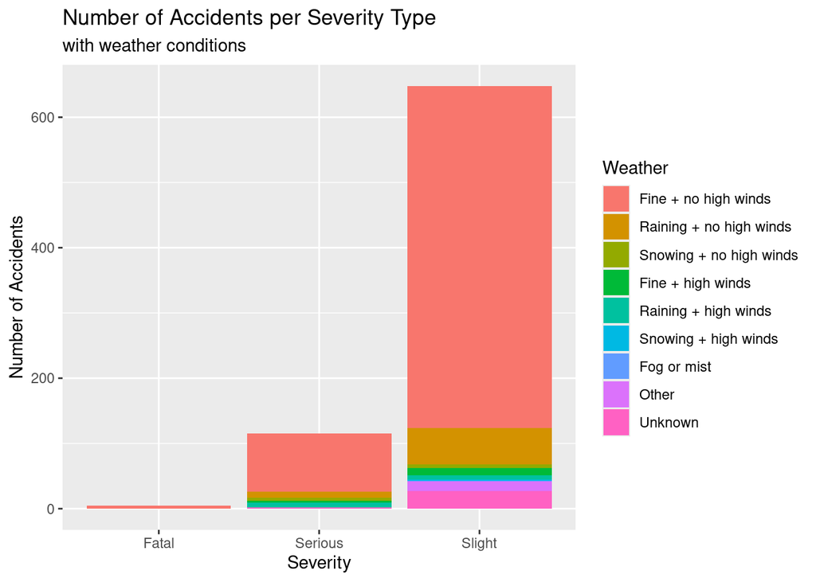

```r
ggplot(accidents, aes(x = factor(severity), fill = weather)) +
  geom_bar() +
  labs(x = 'Severity',
       y = "Number of Accidents",
       fill = "Weather",
       title = "Number of Accidents per Severity Type",
       subtitle = "with weather conditions")
```

#### Recreate the following plot, and describe in context of the data (having the exact same colors or theme is not important).

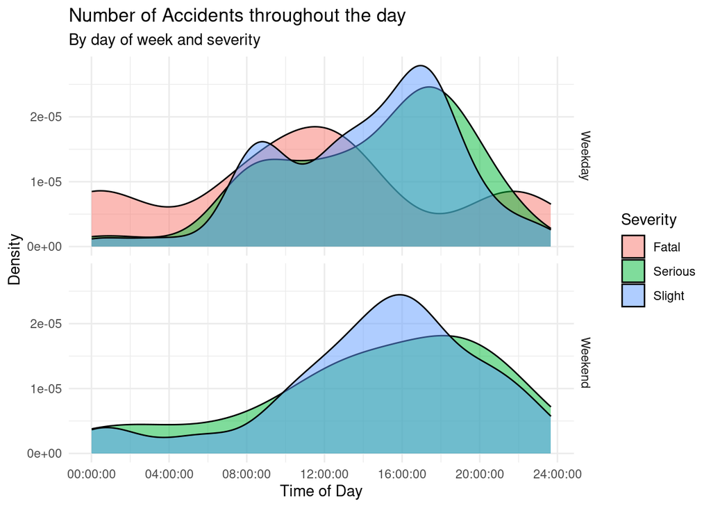

```r
accidents <- accidents %>%
  mutate(day_type = case_when(
    day_of_week == 'Saturday' ~ "Weekend",
    day_of_week == 'Sunday' ~ "Weekend",
    day_of_week == 'Monday' ~ "Weekday",
    day_of_week == 'Tuesday' ~ "Weekday",
    day_of_week == 'Wednesday' ~ "Weekday",
    day_of_week == 'Thursday' ~ "Weekday",
    day_of_week == 'Friday' ~ "Weekday",

  ))


ggplot(accidents, aes(x = time, fill = severity)) +
  geom_density(alpha = 0.5) +
  facet_grid(rows = vars(day_type)) +
  labs(title = 'Number of Accidents throughout the day',
       subtitle = 'By day of week and severity',
       fill = 'Severity',
       y = 'Density',
       x = 'Time of Day') +
  theme_minimal()
```

#### Create another data visualization based on these data and interpret it. You can choose any variables and any type of visualization you like, but it must have at least three variables, e.g. a scatterplot of x vs. y isn’t enough, but if points are colored by z, that’s fine. Interpret your visualization and mention why it is informative.

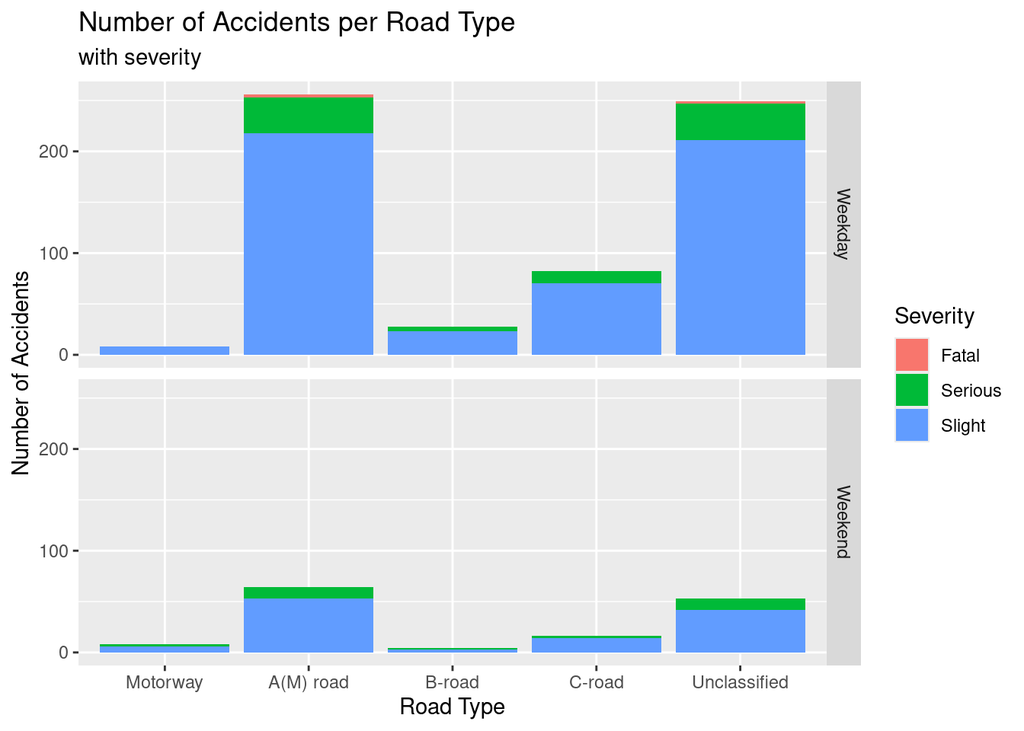

```r
ggplot(accidents, aes(x = factor(first_road_class), fill = severity)) +
  geom_bar() +
  facet_grid(rows = vars(day_type)) +
  labs(x = 'Road Type',
       y = "Number of Accidents",
       fill = "Severity",
       title = "Number of Accidents per Road Type",
       subtitle = "with severity")
```

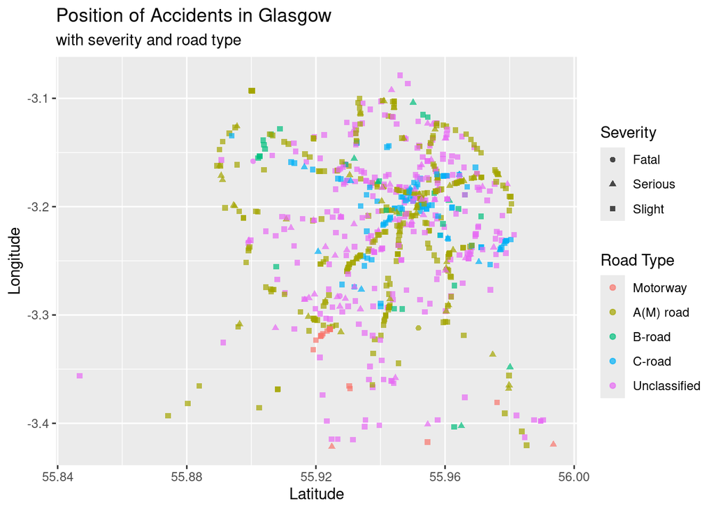

```r
# Bonus plot, nice to see the layout of the city, can clearly see main roads and ring road
ggplot(accidents, aes(x = latitude, y = longitude, color = first_road_class, shape = severity)) +
  geom_point(alpha = 0.7) +
  labs(title = "Position of Accidents in Glasgow",
       subtitle = "with severity and road type",
       x = "Latitude",
       y = "Longitude",
       color = "Road Type",
       shape = "Severity")
```

My bonus plot shows the layout of the city through accidents. Here one can see where the most dangerous or accident prone roads are. This is colored by road type and with shapes showing the severity of the accident. Many accidents occur on intersections and in the city center, with a little cluster around and on the motorway.